# Aims Analysis

```r
library(tidyverse)
library(reshape2)
library(correlation)
library(psych)
library(car)
library(broom)
```

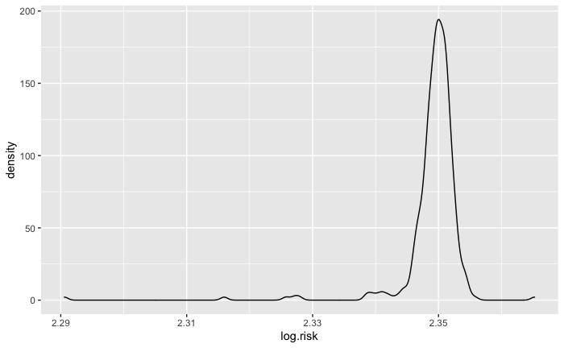

```r
load("../data/Cleaned_Pilot/EDA.RData")
Neuroethics_Judgement %>%
  select(user_id, Risk_Beta, Gain_Beta, age, Income, republican, democrat, independent,
conservative, liberal, Political_Party, ReligionRaised, ReligionNow, Religiosity, Spirituality,
AttendChurch, ReligiousActivity, meditation, Harm, Fairness, Loyalty, Athority, Sancticy) %>%
  distinct() %>%
  mutate(log.risk = log1p(abs(min(Risk_Beta)) + Risk_Beta)) %>%
  mutate(log.gain = log1p(abs(min(Gain_Beta)) + Gain_Beta)) %>%
  filter(!user_id == "tTZWd9tg") %>%
  filter(!user_id == "ZJ8tICU0") %>%
  filter(!user_id == "FIvIqXVg") -> data
data$republican <- factor(data$republican,
                     ordered = TRUE,
                     levels = c("1", "2", "3", "4", "5", "6", "7"))
data$democrat <- factor(data$democrat,
                     ordered = TRUE,
                     levels = c("1", "2", "3", "4", "5", "6", "7"))
data$independent <- factor(data$independent,
                     ordered = TRUE,
                     levels = c("1", "2", "3", "4", "5", "6", "7"))
data$conservative <- factor(data$conservative,
                     ordered = TRUE,
                     levels = c("1", "2", "3", "4", "5", "6", "7"))
data$liberal <- factor(data$liberal,
                     ordered = TRUE,
                     levels = c("1", "2", "3", "4", "5", "6", "7"))
data$Income <-as.character(data$Income)
data$Income <- str_remove(data$Income, "[>,]")
data$Income<- str_trim(data$Income)
data$Income <- as.numeric(data$Income)
####################
ggplot(data, aes(log.risk)) + geom_density()
```

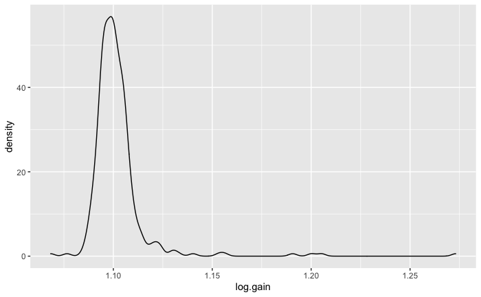

```r
ggplot(data, aes(log.gain)) + geom_density()
```

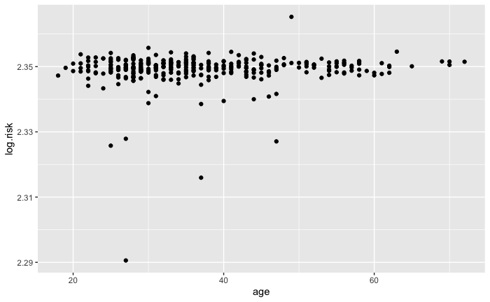

```r
ggplot(data, aes(age,log.risk)) + geom_point()
```

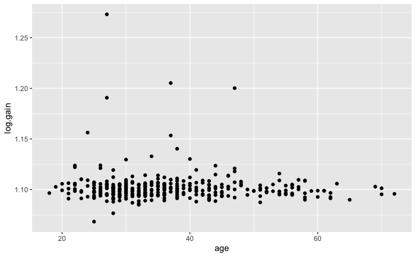

```r
ggplot(data, aes(age,log.gain)) + geom_point()
```

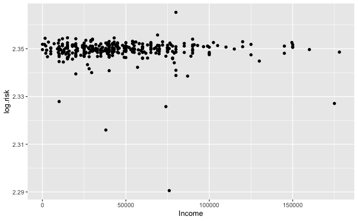

```r
ggplot(data, aes(Income,log.risk)) + geom_point()
```

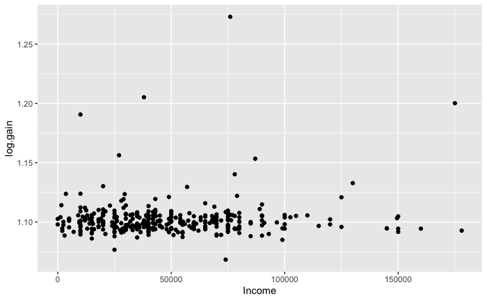

```r
ggplot(data, aes(Income,log.gain)) + geom_point()
```

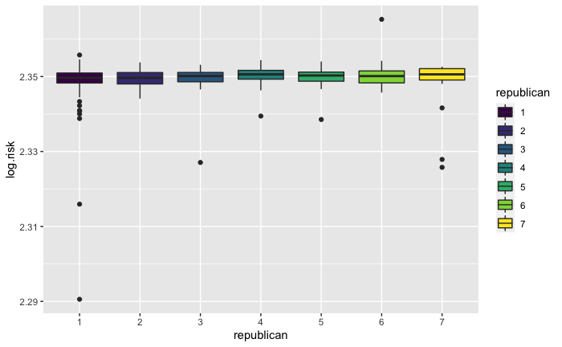

```r
#Republican
ggplot(data, aes(republican, log.risk, fill= republican)) + geom_boxplot()
```

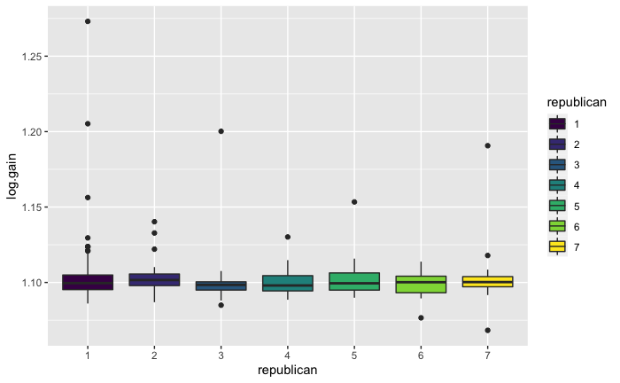

```r
ggplot(data, aes(republican, log.gain, fill= republican)) + geom_boxplot()
```

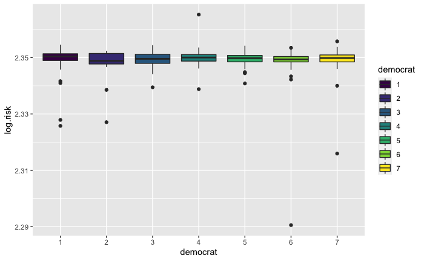

```r
#Democrat
ggplot(data, aes(democrat, log.risk, fill= democrat)) + geom_boxplot()
```

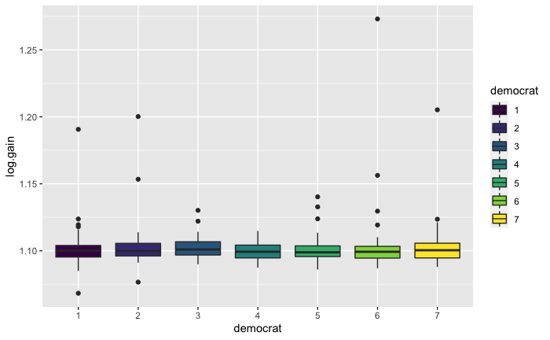

```r
ggplot(data, aes(democrat, log.gain, fill= democrat)) + geom_boxplot()
```

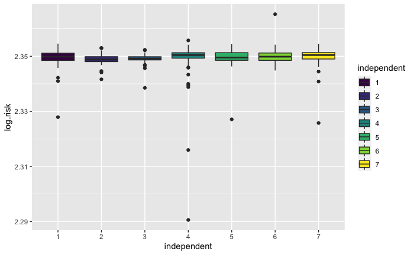

```r
#independent
ggplot(data, aes(independent, log.risk, fill= independent)) + geom_boxplot()
```

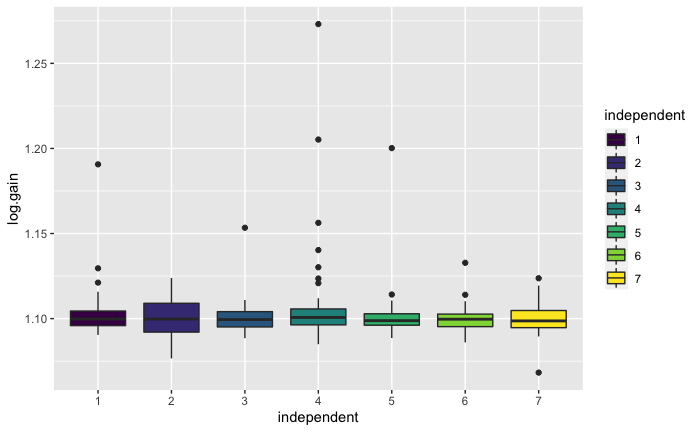

```r
ggplot(data, aes(independent, log.gain, fill= independent)) + geom_boxplot()
```

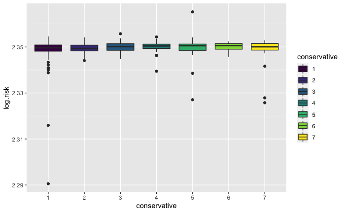

```r
#conservative
ggplot(data, aes(conservative, log.risk, fill= conservative)) + geom_boxplot()
```

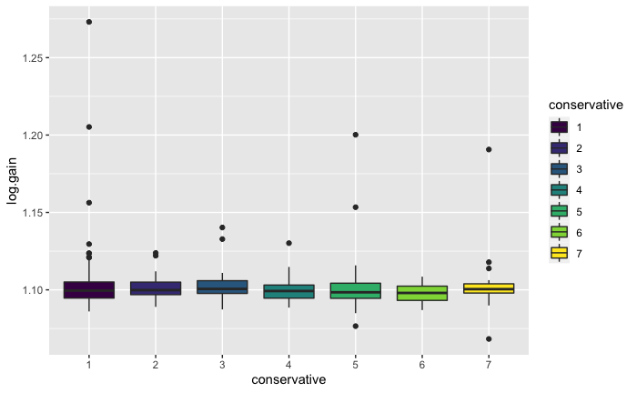

```r
ggplot(data, aes(conservative, log.gain, fill= conservative)) + geom_boxplot()
```

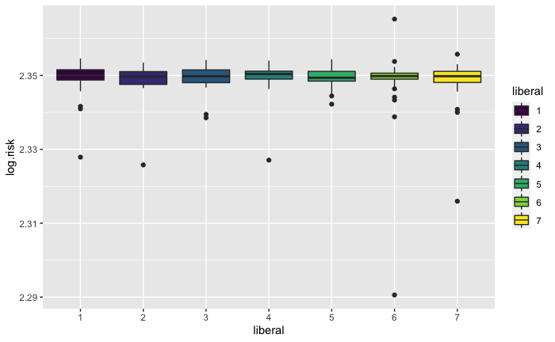

```r
#liberal
ggplot(data, aes(liberal, log.risk, fill= liberal)) + geom_boxplot()
```

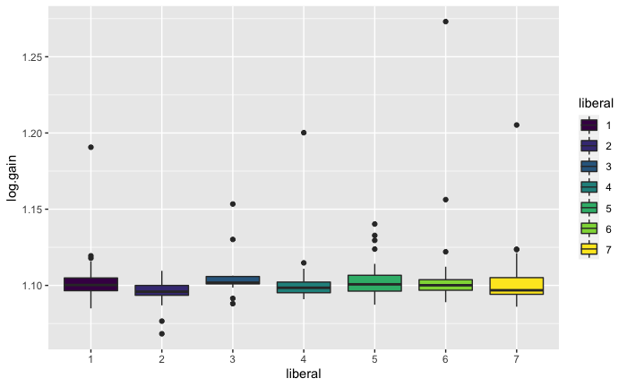

```r
ggplot(data, aes(liberal, log.gain, fill= liberal)) + geom_boxplot()
```

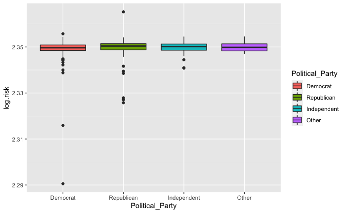

```r
ggplot(data, aes(Political_Party,log.risk, fill = Political_Party)) + geom_boxplot()
```

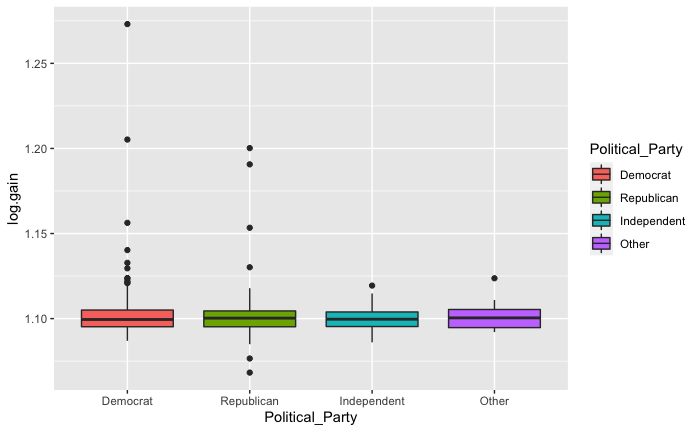

```r
ggplot(data, aes(Political_Party,log.gain, fill = Political_Party)) + geom_boxplot()
```

Prior studies suggest that medical ethical judgments can be influenced by a person’s political ideology and religious values.

We predict liberals and democrats will be, on average, less sensitive to risks of harm, and more sensitive to benefits,

```r
data %>%
  select(log.risk,log.gain, Political_Party) %>%
  filter(Political_Party == "Democrat") -> test
t1 <- t.test(test$log.risk, mu=mean(data$log.risk))
t2 <- t.test(test$log.gain, mu=mean(data$log.gain))
data %>%
  select(log.risk,log.gain, Political_Party) %>%
  filter(Political_Party == "Republican") -> test
t3 <- t.test(test$log.risk, mu=mean(data$log.risk))
t4 <- t.test(test$log.gain, mu=mean(data$log.gain))
tab <- map_df(list(t1,t2,t3,t4), tidy)
knitr::kable(tab[c("estimate" , "statistic" , "conf.low", "conf.high", "p.value")])
```

| estimate | statistic | conf.low | conf.high | p.value |
| --- | --- | --- | --- | --- |
| 2.348892 | -0.7606957 | 2.348003 | 2.349781 | 0.4479378 |
| 1.102786 | 0.5180649 | 1.099967 | 1.105606 | 0.6051154 |
| 2.349082 | -0.2209858 | 2.347708 | 2.350457 | 0.8257561 |
| 1.103316 | 0.5512442 | 1.098722 | 1.107911 | 0.5832470 |

```r
data$democratSUM <-  C(data$democrat, sum)
data$liberalSUM <-  C(data$liberal, sum)
lm.risk.lib <- lm(log.risk~liberalSUM, data = data)
lm.risk.dem <- lm(log.risk~democratSUM, data = data)
lm.gain.lib <- lm(log.gain~liberalSUM, data = data)
lm.gain.dem <- lm(log.gain~democratSUM, data = data)
tab <- map_df(list(lm.risk.lib, lm.risk.dem, lm.gain.lib, lm.gain.dem), tidy)
knitr::kable(tab[c("term", "estimate", "std.error", "statistic", "p.value")])
```

| term | estimate | std.error | statistic | p.value |
| --- | --- | --- | --- | --- |
| (Intercept) | 2.3491686 | 0.0003013 | 7796.9427713 | 0.0000000 |
| liberalSUM1 | 0.0005384 | 0.0006036 | 0.8920312 | 0.3730184 |
| liberalSUM2 | -0.0005240 | 0.0008802 | -0.5953256 | 0.5520290 |
| liberalSUM3 | -0.0002863 | 0.0010132 | -0.2826027 | 0.7776565 |
| liberalSUM4 | 0.0005676 | 0.0006849 | 0.8286978 | 0.4078672 |
| liberalSUM5 | 0.0002432 | 0.0006736 | 0.3610317 | 0.7183040 |
| liberalSUM6 | -0.0004589 | 0.0006390 | -0.7182030 | 0.4731342 |
| (Intercept) | 2.3490591 | 0.0003010 | 7803.5558223 | 0.0000000 |
| democratSUM1 | 0.0005532 | 0.0005367 | 1.0307093 | 0.3034229 |
| democratSUM2 | -0.0008398 | 0.0009071 | -0.9258462 | 0.3551944 |
| democratSUM3 | 0.0002090 | 0.0009431 | 0.2216066 | 0.8247556 |
| democratSUM4 | 0.0009997 | 0.0006816 | 1.4667759 | 0.1433779 |
| democratSUM5 | 0.0003458 | 0.0006154 | 0.5618472 | 0.5745970 |
| democratSUM6 | -0.0013562 | 0.0007699 | -1.7615647 | 0.0790577 |
| (Intercept) | 1.1019598 | 0.0009548 | 1154.0836574 | 0.0000000 |
| liberalSUM1 | 0.0003873 | 0.0019129 | 0.2024913 | 0.8396560 |
| liberalSUM2 | -0.0062221 | 0.0027894 | -2.2306645 | 0.0263671 |
| liberalSUM3 | 0.0035911 | 0.0032111 | 1.1183332 | 0.2642284 |
| liberalSUM4 | -0.0004653 | 0.0021706 | -0.2143449 | 0.8304089 |
| liberalSUM5 | 0.0013017 | 0.0021346 | 0.6098057 | 0.5424051 |
| liberalSUM6 | 0.0023947 | 0.0020250 | 1.1825433 | 0.2378313 |
| (Intercept) | 1.1027008 | 0.0009619 | 1146.4201726 | 0.0000000 |
| democratSUM1 | -0.0016513 | 0.0017150 | -0.9628651 | 0.3363118 |
| democratSUM2 | 0.0033493 | 0.0028985 | 1.1555391 | 0.2486957 |
| democratSUM3 | 0.0004204 | 0.0030135 | 0.1395003 | 0.8891389 |
| democratSUM4 | -0.0031169 | 0.0021778 | -1.4312334 | 0.1532983 |
| democratSUM5 | -0.0018099 | 0.0019664 | -0.9204132 | 0.3580212 |
| democratSUM6 | 0.0030612 | 0.0024600 | 1.2443946 | 0.2142269 |

while conservatives and republicans will be more sensitive to risk of harm, and less sensitive to benefits.

```r
data$republicanSUM <- C(data$republican, sum)
data$conservativeSUM <- C(data$conservative, sum)
lm.risk.rep <- lm(log.risk~republicanSUM, data = data)
lm.risk.con <- lm(log.risk~conservativeSUM, data = data)
lm.gain.rep <- lm(log.gain~republicanSUM, data = data)
lm.gain.con <- lm(log.gain~conservativeSUM, data = data)
tab <- map_df(list(lm.risk.rep, lm.risk.con, lm.gain.rep, lm.gain.con), tidy)
knitr::kable(tab[c("term", "estimate", "std.error", "statistic", "p.value")])
```

| term | estimate | std.error | statistic | p.value |
| --- | --- | --- | --- | --- |
| (Intercept) | 2.3494986 | 0.0003475 | 6760.3576856 | 0.0000000 |
| republicanSUM1 | -0.0005755 | 0.0004685 | -1.2284038 | 0.2201603 |
| republicanSUM2 | -0.0000429 | 0.0008003 | -0.0535682 | 0.9573112 |
| republicanSUM3 | -0.0003224 | 0.0008946 | -0.3603990 | 0.7187766 |
| republicanSUM4 | 0.0007461 | 0.0007910 | 0.9432682 | 0.3462255 |
| republicanSUM5 | 0.0000869 | 0.0009257 | 0.0938283 | 0.9253018 |
| republicanSUM6 | 0.0011509 | 0.0010500 | 1.0961714 | 0.2737935 |
| (Intercept) | 2.3495325 | 0.0003208 | 7324.3658330 | 0.0000000 |
| conservativeSUM1 | -0.0008380 | 0.0004738 | -1.7684913 | 0.0778915 |
| conservativeSUM2 | -0.0000578 | 0.0007301 | -0.0791573 | 0.9369549 |
| conservativeSUM3 | 0.0004518 | 0.0008087 | 0.5586339 | 0.5767859 |
| conservativeSUM4 | 0.0005363 | 0.0007789 | 0.6885010 | 0.4916153 |
| conservativeSUM5 | 0.0001892 | 0.0007530 | 0.2512215 | 0.8017973 |
| conservativeSUM6 | 0.0006512 | 0.0010405 | 0.6258660 | 0.5318303 |
| (Intercept) | 1.1017043 | 0.0011134 | 989.4769434 | 0.0000000 |
| republicanSUM1 | 0.0005650 | 0.0015010 | 0.3764591 | 0.7068147 |
| republicanSUM2 | 0.0019462 | 0.0025639 | 0.7590829 | 0.4483383 |
| republicanSUM3 | 0.0000573 | 0.0028662 | 0.0200092 | 0.9840480 |
| republicanSUM4 | -0.0011085 | 0.0025340 | -0.4374467 | 0.6620701 |
| republicanSUM5 | 0.0003872 | 0.0029658 | 0.1305568 | 0.8962045 |
| republicanSUM6 | -0.0033794 | 0.0033638 | -1.0046494 | 0.3157930 |
| (Intercept) | 1.1014973 | 0.0010282 | 1071.2949146 | 0.0000000 |
| conservativeSUM1 | 0.0011676 | 0.0015188 | 0.7687617 | 0.4425781 |
| conservativeSUM2 | 0.0001823 | 0.0023401 | 0.0778868 | 0.9379648 |
| conservativeSUM3 | 0.0012020 | 0.0025921 | 0.4637084 | 0.6431587 |
| conservativeSUM4 | -0.0013183 | 0.0024967 | -0.5280111 | 0.5978423 |
| conservativeSUM5 | 0.0011458 | 0.0024135 | 0.4747340 | 0.6352868 |
| conservativeSUM6 | -0.0036327 | 0.0033350 | -1.0892410 | 0.2768329 |

Testing for means differences between dems and reps

```r
data %>%
  select(user_id, Political_Party, log.risk, log.gain) -> subset
subset <- subset(subset, Political_Party != "Independent")
subset <- subset(subset, Political_Party != "Other")
# Sort by beta type then user_id so that the t test function reads it
subset <- subset[order(subset$Political_Party, subset$user_id), ]
# Welch t-test
#tests differences between rep and dems on each of our responses
t1 <- t.test(log.risk ~ Political_Party, subset, var.equal=TRUE)
t2 <- t.test(log.gain ~ Political_Party, subset, var.equal=TRUE)
#create table
tab <- map_df(list(t1, t2), tidy)
knitr::kable(tab[c("method","estimate", "statistic", "conf.low", "conf.high", "p.value")])
```

| method | estimate | statistic | conf.low | conf.high | p.value |
| --- | --- | --- | --- | --- | --- |
| Two Sample t-test | -0.0001901 | -0.2309971 | -0.0018116 | 0.0014314 | 0.8175206 |
| Two Sample t-test | -0.0005298 | -0.1996756 | -0.0057575 | 0.0046979 | 0.8419092 |

Consistent with the literature, we also predict that those who are more religious will be, on average, more sensitive to risks of harm.

```r
data %>%
  select(user_id, log.risk, log.gain, ReligionRaised, ReligionNow, Religiosity, Spirituality,
AttendChurch, ReligiousActivity) -> data.religious
#we need a change variable if you changed relgion
data.religious <- mutate(data.religious, ReligionChanged = data.religious$ReligionRaised == data.religious$ReligionNow)
data.religious$ReligionChanged <- factor(data.religious$ReligionChanged, labels = c("Yes","No"))
religious <- data.matrix(data.religious[,c(6:10)]) - 1
#Check for number of factors
religious.cov <- psych::polychoric(religious)$rho
```

```
10 cells were adjusted for 0 values using the correction for continuity. Examine your data carefully.Matrix was not positive definite, smoothing was done
```

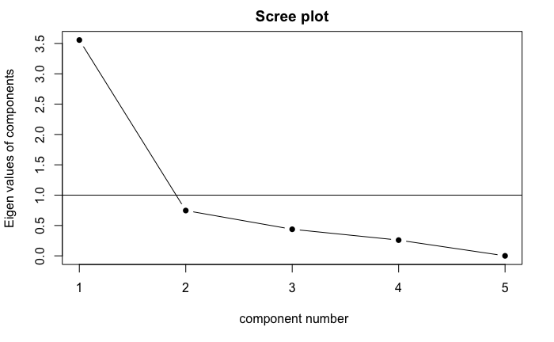

```r
evals <- eigen(religious.cov)$values
scree(religious.cov, factors = F)
```

```r
(evals/sum(evals)*100)[1:5]
```

```
[1] 7.112091e+01 1.493511e+01 8.759082e+00 5.184901e+00 1.980874e-09
```

```r
religious.efa <- fa(religious, nfactors = 1, rotate = "oblimin", fm ="ml", cor = "poly", scores = "regression")
```

```
10 cells were adjusted for 0 values using the correction for continuity. Examine your data carefully.Matrix was not positive definite, smoothing was done
```

```r
print(religious.efa$loadings, cutoff = "0.3")
```

```
Loadings:
                  ML1
Religiosity       0.998
Spirituality      0.732
AttendChurch      0.816
ReligiousActivity 0.767
ReligionChanged   0.742

                 ML1
SS loadings    3.336
Proportion Var 0.667
```

```r
religious.factor_scores<- religious.efa$scores
data.religious <- cbind(data.religious, religious.factor_scores)
colnames(data.religious) <- c("user_id", "log.risk", "log.gain", "ReligionRaised", "ReligionNow",
"Religiosity", "Spirituality", "AttendChurch", "ReligiousActivity",
"ReligionChanged", "ReligiousFactor")
#test
correlation::correlation(data.religious)
```

```
Parameter1 |      Parameter2 |     r |         95% CI |      t |  df |      p |  Method | n_Obs
-----------------------------------------------------------------------------------------------
log.risk   |        log.gain | -0.71 | [-0.76, -0.65] | -18.48 | 339 | < .001 | Pearson |   341
log.risk   | ReligiousFactor |  0.16 | [ 0.05,  0.26] |   2.89 | 339 | 0.008  | Pearson |   341
log.gain   | ReligiousFactor | -0.11 | [-0.21,  0.00] |  -1.95 | 339 | 0.053  | Pearson |   341
```

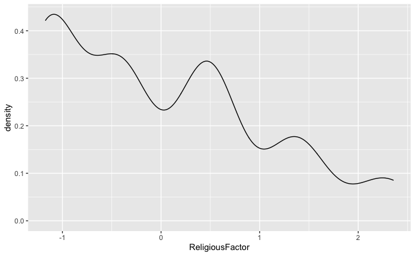

```r
ggplot(data.religious, aes(ReligiousFactor)) + geom_density()
```

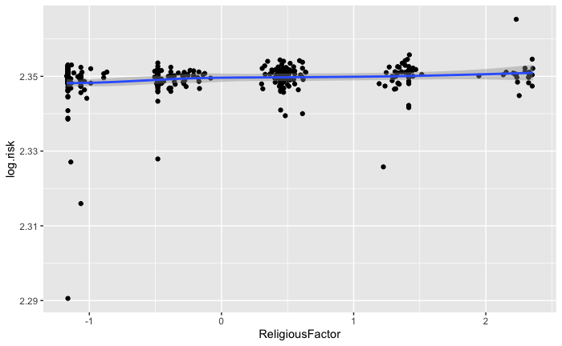

```r
ggplot(data.religious, aes(ReligiousFactor, log.risk)) + geom_point() + geom_smooth()
```

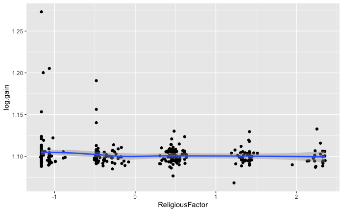

```r
ggplot(data.religious, aes(ReligiousFactor, log.gain)) + geom_point()+ geom_smooth()
```

```r
summary(data.religious$ReligionNow)
```

```
       Christianity             Judaism               Islam Unitarian Universal            Buddhism            Hinduism         Agnosticism            Athesism
                154                   2                   3                   1                   5                   6                  61                  57
           Humanism            Paganism                None               Other
                  2                   2                  43                   5
```

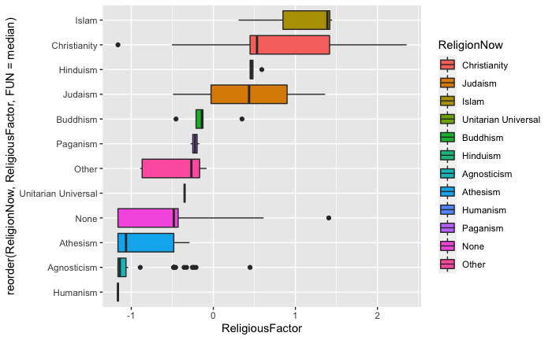

```r
ggplot(data.religious) +
  geom_boxplot(aes(reorder(ReligionNow, ReligiousFactor, FUN = median),ReligiousFactor, fill = ReligionNow)) +
  coord_flip()
```

```r
lm.risk.relig <- lm(log.risk~ReligiousFactor, data = data.religious)
lm.gain.relig <- lm(log.gain~ReligiousFactor, data = data.religious)
tab <- map_df(list(lm.risk.relig, lm.gain.relig), tidy)
knitr::kable(tab[c("term", "estimate", "std.error", "statistic", "p.value")])
```

| term | estimate | std.error | statistic | p.value |
| --- | --- | --- | --- | --- |
| (Intercept) | 2.3492346 | 0.0002658 | 8836.840401 | 0.0000000 |
| ReligiousFactor | 0.0007394 | 0.0002558 | 2.890550 | 0.0040936 |
| (Intercept) | 1.1020467 | 0.0008540 | 1290.386782 | 0.0000000 |
| ReligiousFactor | -0.0015987 | 0.0008217 | -1.945521 | 0.0525386 |

```r
data.religious$ReligionNowSUM <-  C(data.religious$ReligionNow, sum)
lm.risk.relig.control <- lm(log.risk~ ReligiousFactor + ReligionNowSUM, data = data.religious)
lm.gain.relig.control <- lm(log.gain~ ReligiousFactor + ReligionNowSUM, data = data.religious)
tab <- map_df(list(lm.risk.relig.control, lm.gain.relig.control), tidy)
knitr::kable(tab[c("term", "estimate", "std.error", "statistic", "p.value")])
```

| term | estimate | std.error | statistic | p.value |
| --- | --- | --- | --- | --- |
| (Intercept) | 2.3494468 | 0.0007688 | 3055.8987989 | 0.0000000 |
| ReligiousFactor | 0.0003004 | 0.0004416 | 0.6802604 | 0.4968195 |
| ReligionNowSUM1 | 0.0002884 | 0.0009629 | 0.2995165 | 0.7647357 |
| ReligionNowSUM2 | 0.0000519 | 0.0032873 | 0.0157805 | 0.9874191 |
| ReligionNowSUM3 | 0.0023582 | 0.0027639 | 0.8532356 | 0.3941513 |
| ReligionNowSUM4 | -0.0014736 | 0.0045711 | -0.3223650 | 0.7473815 |
| ReligionNowSUM5 | 0.0014701 | 0.0021556 | 0.6819675 | 0.4957408 |
| ReligionNowSUM6 | -0.0008300 | 0.0020126 | -0.4123951 | 0.6803192 |
| ReligionNowSUM7 | -0.0018787 | 0.0010225 | -1.8373932 | 0.0670563 |
| ReligionNowSUM8 | -0.0000321 | 0.0010170 | -0.0315727 | 0.9748320 |
| ReligionNowSUM9 | -0.0000410 | 0.0033064 | -0.0124102 | 0.9901059 |
| ReligionNowSUM10 | 0.0007112 | 0.0032768 | 0.2170283 | 0.8283212 |
| ReligionNowSUM11 | -0.0001746 | 0.0010515 | -0.1660793 | 0.8681968 |
| (Intercept) | 1.1011992 | 0.0024326 | 452.6813166 | 0.0000000 |
| ReligiousFactor | 0.0007166 | 0.0013974 | 0.5127959 | 0.6084393 |
| ReligionNowSUM1 | -0.0021229 | 0.0030466 | -0.6968010 | 0.4864209 |
| ReligionNowSUM2 | 0.0012427 | 0.0104014 | 0.1194734 | 0.9049735 |
| ReligionNowSUM3 | -0.0005524 | 0.0087451 | -0.0631628 | 0.9496753 |
| ReligionNowSUM4 | -0.0069392 | 0.0144633 | -0.4797822 | 0.6317020 |
| ReligionNowSUM5 | -0.0050096 | 0.0068206 | -0.7344839 | 0.4631786 |
| ReligionNowSUM6 | 0.0042005 | 0.0063680 | 0.6596219 | 0.5099594 |
| ReligionNowSUM7 | 0.0092726 | 0.0032351 | 2.8662076 | 0.0044226 |
| ReligionNowSUM8 | 0.0011045 | 0.0032178 | 0.3432596 | 0.7316231 |
| ReligionNowSUM9 | -0.0072642 | 0.0104617 | -0.6943628 | 0.4879462 |
| ReligionNowSUM10 | 0.0078475 | 0.0103682 | 0.7568778 | 0.4496664 |
| ReligionNowSUM11 | 0.0000272 | 0.0033272 | 0.0081701 | 0.9934862 |

# Exploration

Aim 2) To explore the relationship between existing moral intuitions and judgments about abstract technologies involving a risk of harm and likelihood of gain.

[output not shown]

Consistent with MFT we hypothesize that higher scores on foundations of Authority, Loyalty, and Sanctity will be more risk averse than those who score high on Harm and Fairness.

Winsorization began as a way to "robustify" the sample mean, which is sensitive to extreme values. To obtain the Winsorized mean, you sort the data and replace the smallest k values by the (k+1)st smallest value. You do the same for the largest values, replacing the k largest values with the (k+1)st largest value. The mean of this new set of numbers is called the Winsorized mean. If the data are from a symmetric population, the Winsorized mean is a robust unbiased estimate of the population mean.